# Using co-design workshops to explore community needs and future directions for shared electric mobility hubs

James Reynolds, Noreen Armstrong, Brian McCann, Amaya Vega, Agnieszka Stefaniec, Brian Caulfield and Sarbast Moselm

2026-09-16

# Abstract

Railway stations, bus stops, post offices and similar facilities can often provide an important focus for communities, including as a central hub for the movement of people and goods, and places of social interaction. Recent research directions have: emphasised the ‘Place’ function of road (and other transport) facilities as a vital and additional dimension, alongside the more traditional focus of transport systems for through movement and access to adjoining land uses; introduced the concept of shared electric mobility hubs, which seek to provide a central location at which travelers and nearby residents might have access to electric cars, e-cargo bikes, e-bikes or other modes that might support more sustainable travel choices, especially in contexts where the provision of high frequency transit services may be challenging (e.g. regional towns, rural communities, low-density suburbs); and suggested the adoption of person-centric design approaches such as co-design, from industrial design and related fields, by researchers and practitioners in transport. However, it is unclear what form such shared electric mobility hubs should take, and how such industrial design methodologies might be used in their development.  
The extent to which the co-location of other facilities (e.g. library, café, bus stop, community house) might enhance usage, safety and security (c.f. Jane Jacob’s “eyes on the street”) and local communities, or how new tools for crime prevention recent developed in the context of public transport might be adapted to mobility hubs.

Four shared e-mobility hubs have recently been implemented in Letterkenny, Galway, Waterford and the suburbs of Dublin. These include e-bikes, e-cargo bikes, and shared electric cars as part of the ‘base’ offering, as well as *power infrastructure* to support recharging of these vehicles, *and other (future) uses*. These represent a considerable capital investment and potential for improved mobility for these locations, but also the potential to support individual and community needs and grow the ‘mobility offer’ through supporting programs,

However, it is unclear what additional mobility, community-focused, commercial or other offerings might be desired by communities, or might help to support the use of shared e-mobility hub facilities to improve transport sustatinability. Perhaps such hubs can help to make existing programs (e.g. meals-on-wheels, council officer trips, inter-library loans) more sustainable? Or perhaps such hubs might become places in and of themselves, with a similar mix of services and facilities as might be found in a railway station.

# Introduction

Current understandings of how to design and implement transit stations and stops, roadways and streets, and other elements of the public realm have developed over long periods of time. Green et al. (1995), Beanland (2024) and many others discuss some of the more formal processes and their outputs, while Engwicht (1999), Lydon et al. (2012), Lydon and Garcia (2015) and others outline street reclaiming, tactical urbanism and similar (and often citizen-led) efforts to reorganise public roads. As well, while road and rail systems and practices are well established, shifts of emphasis and technology change are inevitably leading to new problems, the need for new solutions, or just different ways of doing things. Examples include: the introduction of new vehicle and stop types that allow for level-boarding access to transit, which has been driven by legislative change related to human rights, discrimination and accessibility (Currie and Smith 2006); the development of electric vehicles, demand responsive transit systems, the concepts related to Mobility as a Service (MaaS), autonomous vehicles, and changes due to the modern proliferation of mobile communications technologies, shared and micromobility systems and many more (see Nelson et al. (2025) and others).

Green, Oliver, Jeremy Rewse-Davies, and London Transport Museum. 1995. *Designed for London: 150 Years of Transport Design*. Laurence King.

Beanland, Christopher. 2024. *Station: A Journey Through 20th and 21st Century Railway Architecture and Design*. Batsford Books.

Engwicht, David. 1999. *Street Reclaiming : Creating Livable Streets and Vibrant Communities*. Sydney : Pluto Press.

Lydon, Mike, Dan Bartman, Tony Garcia, Russ Preston, and Ronald Woudstra. 2012. *Tactical Urbanism 2; Short-Term Action, Long-Term Change*. The Street Plans Collaborative.

Lydon, Mike, and Anthony Garcia. 2015. *Tactical Urbanism : Short-Term Action for Long-Term Change*. Island Press.

Currie, Graham, and Paul Smith. 2006. “Innovative Design for Safe and Accessible Light Rail or Tram Stops Suitable for Streetcar-Style Conditions.” Conference Paper. *Transportation Research Record: Journal of the Transportation Research Board* 1955: 37–46.

Nelson, John D., Corinne Mulley, and Stephen Ison. 2025. *Elgar Encyclopedia of Transport and Society*. Edward Elgar Publishing. https://doi.org/10.4337/9781035330522.

Shared electric mobility hubs are one of these many recent developments, which necessitate the development and refinement of designs and practices to transition from an initial concept to more established and relatively easily implementable products. The initial concept is relatively simple, and responds to many of the problems that have emerged with dockless electric bike and scooter systems. These include poor user behaviour with respect to parking, a need for workers to reposition vehicles and replace batteries, and the risk of fires when battery recharging is done using non-bespoke or appropriately desgined facilities (e.g. in gig-workers’ houses)(see Zhang et al. (2022), Meigs (2023), Ferguson and Blandino (2025) and others). Instead, a shared electric mobility hub provides dedicated parking, electrical connections and other facilitates for electric bikes, cars or other vehicles, which are made available on an as-needed and shared basis to the general public. Charging occurs at the hub, while hires involve both outward and return journeys rather than point-to-point trips.

Zhang, Ze, Yuchen Guo, and Li Feng. 2022. “Externalities of Dockless Bicycle-Sharing Systems: Implications for Green Recovery of the Transportation Sector.” *Economic Analysis and Policy* 76: 410–19.

Meigs, James B. 2023. “The Dark Side of ‘Micro-Mobility’; Tragedies Like This Week’s e-Bike Repair Shop Fire Highlight the Hidden Dangers That Personal Vehicles Powered by Lithium-Ion Batteries Pose to Urban Environments.” *City Journal*, NA–.

Ferguson, Beth, and Jordan Scott Blandino. 2025. *Shared Micromobility Vehicle Design and Safety*.

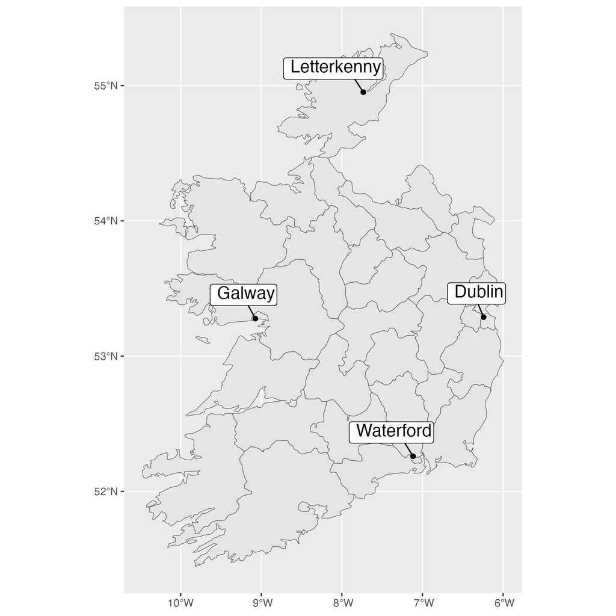

ROBUST hub locations within the Republic of Ireland

Industrial design as a field often deals with the manufacturing of consumer products, specialised devices or similar. While transport applications may have tended more towards the design and manufacturing of private motor cars, Coxon et al. (2018), Coxon et al. (2021) and Coxon and Napper (2021) insights into how industrial design and its methodologies might help to inform the research related to the design, implementation and operation of transit and transport systems more generally. This paper, therefore, describes efforts to put such methods into research activity related to user-centric and co-design approaches to shared electricity mobility hub design and implementation, through the context of the ROBUST case study sites. Findings from these activities may provide insights for researchers and practitioners as to how mobility hubs might be designed and implemented to better met the needs of users and communities, and help towards responding to the current pressing need to move towards more sustainable transportation systems.

Coxon, Selby, Robbie Napper, and Mark Richardson. 2018. *Urban Mobility Design*. Elsevier.

Coxon, Selby, Robbie Napper, Ilya Fridman, and Vincent Moug. 2021. “The Power of Design to Enrich the Public Transport Experience.” Chap. 6 in *Handbook of Public Transport Research*. Edward Elgar Publishing.

Coxon, Selby, and Robbie Napper. 2021. “Preface II.” In *Advancing a Design Approach to Enriching Public Mobility*, edited by Selby Coxon and Robbie Napper. Springer.

The next section of this paper describes the research background and context for this study. Methods used during the case studies are then outlined,followed by presentation of results. These are discussed prior to a brief conclusion, which includes the identification of directions for future research.

# Research background

A bibliometric mapping analysis and review of literature relevant to the ROBUST project is reported elsewhere in Reynolds et al. (in draftingc), but in general describes the various beginnings of the ‘mobility hub’ concept. These include use of the term in the Greater Toronto and Hamilton Area (GTHA) in Ontario, Canada, related to the Metrolinx regional planning authorities ‘Big Move’ plan Engel-Yan et al. (2014). This envisages ‘mobility hubs’ as encompassing areas within and around regionally significant transit stations and stops, where planning and infrastructure interventions would be used to facilitate inter-modal transfers, Transit Oriented Development (TOD) and other elements. Such concepts relate back to much previous research into TOD, including with respect to the “3Ds: Density, Diversity, and Design” (Cervero and Kockelman 1997), plus “Destination, Distance, and Demand” in Ogra and Ndebele (2014), but also to slightly earlier developments in Europe including integration of trams and trains at a station in Augsburg, Germany (Beyer and Lochbihler 2005), and shifts towards greater consideration of both ‘Movement’ and ‘Place’ in the UK and Australia Bradbury et al. (2007), and ‘Complete Streets’ in North America Delbosc et al. (2018). Earlier still, Mees (2000) recounted the challenges faced by users of Melbourne’s transit system in transferring between separately operated bus and train routes, before detailed examinations of Switzerland’s network-focused approach, including through the nation-wide ‘clock-face timetable’ such that even locations with infrequent services have pulsed and coordinated arrivals and departures of buses, trams and trains such that users are virtually guaranteed a connected journey across modes and operators.

Reynolds, James, Amaya Vega, Brian McCann, Agnieszka Stefaniec, and Brian Caulfield. in draftingc. “ROBUST - Electric shaRed mOBility hUbS Trial: Science Mapping Analysis and Literature Review.” *TBC*, in drafting.

Engel-Yan, Joshua B., Malvika Rudra, Christopher Livett, and Rebecca Nagorsky. 2014. “Strategic Station Access Planning for Commuter Rail Balancing Park-and-Ride with Other Modes.” Review. *Transportation Research Record* 2419: 82–91. https://doi.org/10.3114/2419-08.

Cervero, Robert, and Kara Kockelman. 1997. “Travel Demand and the 3Ds: Density, Diversity, and Design.” *Transportation Research Part D: Transport and Environment* 2 (3): 199–219.

Ogra, Aurobindo, and Robert Ndebele. 2014. *The Role of 6Ds: Density, Diversity, Design, Destination, Distance, and Demand Management in Transit Oriented Development (TOD)*.

Beyer, Martin, and Edmund Lochbihler. 2005. “The Augsburg Mobility Hub Construction of a New Underground Tram Crossing at the Main Station; Mobilitätsdrehscheibe Augsburg: Neubau Eines Unterirdischen Straßenbahnkreuzes Am Hciuptbahnhof.” Review. *Eisenbahningenieur* 56 (11): 18–22.

Bradbury, Annabel, Andrew Cameron, Ben Castell, et al. 2007. *Manual for Streets*. Department for Transport; Publishing, Thomas Telford.

Delbosc, Alexa, James Reynolds, Wesley Marshall, and Andrew Wall. 2018. “American Complete Streets and Australian SmartRoads: What Can We Learn from Each Other?” *Transportation Research Record*.

Mees, Paul. 2000. *A Very Public Solution : Transport in the Dispersed City*. Melbourne University Press.

User-centric design and consideration of more than just the operational needs and efficiency of service provision also comes up in the emerging use of Crime Prevention Through Environmental Design (CPTED) approaches within transport contexts. Security and personal safety are a significant concern for transport operators and users, and attracts much researcher attention (Beecroft 2025), but the new tools for assessing station environments from a user safety and security perspective from Currie et al. (2021) might provide opportunities to ‘design out’ such problems rather than having to react through enforcement activity. Likewise, Killen (2021) reports design-based interventions that remove opportunities for the vandalism of railway vehicles, developed through use of industrial design methodologies that focus on the needs of end users (in this instance train operators) as part of a holistic approach to design and manufacturing.

Beecroft, Mark. 2025. “Security.” In *Elgar Encyclopedia of Transport and Society*, edited by John D. Nelson, Corinne Mulley, and Stephen Ison. Edward Elgar Publishing. https://doi.org/10.4337/9781035330522-00181.

Currie, Graham, Mustafizur Rahaman, Carlyn Muir, and Alexa Delbosc. 2021. “Personal Safety on Public Transport: Research Frontiers and New Tools for an Old Problem.” In *Handbook of Public Transport Research*. Edward Elgar Publishing.

Killen, Amy. 2021. “Mitigating Rail Vandalism Through Design Intervention.” Chap. 14 in *Advancing a Design Approach to Enriching Public Mobility*, edited by Selby Coxon and Robbie Napper. Springer.

Clearly some such industrial design methodologies have been applied in the development of the many emerging shared and micro-mobility offerings that have arrived on city streets in the last decade. In general, however, such efforts appear to have focused on the needs of operators, especially with respect to attracting users, given that most have emerged within the market context of venture capitalism, competitive and unsubsidised markets, and with regulations either not applying, not being adequately enforced, or in development as regulatory agencies seek to respond to disruption and rapid change. In *Lies, Damned Lies, AVs, Shared Mobility, and Urban Transit Futures* Currie (2018) discusses how many of these emerging mobilities might be over-hyped, not actually offering “shared” transport, and otherwise distorting systems and distracting attention away from solutions that have been proven through decades or even centuries of design, operations, refinement and redesign, and continuous development. To an extent, however, issues such as gig-workers’ residences or contracts’ business premises catching on fire while piles of batteries recharge (e.g. Meigs (2023)) might be related more to the lack of holistic design that takes the needs of users, manufactures and society at large in account, and that designs entire systems. Along these lines Zhang et al. (2022) discusses how the benefits of current dockless bike share systems might be offset by carbon emmissions invovled in manufacture and maintenance, and rebalancing of network assests, while Ferguson and Blandino (2025) highlights the poor build quality of many such vehicles and systems that have been rushed into distorted markets.

Currie, Graham. 2018. “Lies, Damned Lies, AVs, Shared Mobility, and Urban Transit Futures.” *Journal of Public Transportation* 21 (1): 19–30.

Meigs, James B. 2023. “The Dark Side of ‘Micro-Mobility’; Tragedies Like This Week’s e-Bike Repair Shop Fire Highlight the Hidden Dangers That Personal Vehicles Powered by Lithium-Ion Batteries Pose to Urban Environments.” *City Journal*, NA–.

Zhang, Ze, Yuchen Guo, and Li Feng. 2022. “Externalities of Dockless Bicycle-Sharing Systems: Implications for Green Recovery of the Transportation Sector.” *Economic Analysis and Policy* 76: 410–19.

Ferguson, Beth, and Jordan Scott Blandino. 2025. *Shared Micromobility Vehicle Design and Safety*.

The ROBUST hubs may represent the next iteration in shared electrified mobility design, or at least prototypes as an incremental step towards more sustainable and effective components of transport systems. Prototypes are useful, however, because they are a tool for discovering problems, defining issues, developing and then delivering the next, better, iteration. These are the alternate converging and diverging steps detailed in the UK Design Council (undated) Double Diamond design process and Framework for Innovation (Figure $\ref{fig:double_diamond}$).

UK Design Council. undated. *The Double Diamond*. undated. https://www.designcouncil.org.uk/our-resources/the-double-diamond/.

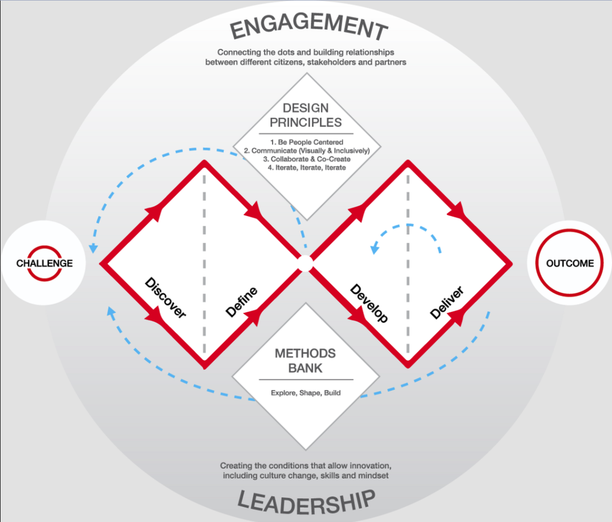

Framework for Innovation. Sourece : UK Design Council (undated)

This framework involves iteration within the overall process, which is focused around converging first to a definition of the problem, and then delivering an outcome (‘the design’). In contrast, more traditional civil engineering processes have often tended towards a multi-phased approach, wherein a project progresses from feasibility, through concept and preliminary design stages, towards a detailed design that then forms the basis for tendering and/or construction (see for example State Library NSW (2025) and Hillier (2022)). While this includes many steps, the entire process appears to be involve just a single convergence on delivering a detailed design. Techno-rational policy-cycle models that dominate transport policy-making (Marsden and Reardon 2017) may involve some divergence within issue identification and options generating steps, but tend to leave convergence until post-analysis decision-making, while iteration happens through evaluation, to start the next policy cycle, rather than within a single turning.

State Library NSW. 2025. *Understanding Project Phases*. https://pls.sl.nsw.gov.au/managing-my-library/buildings-and-spaces/people-places/planning/understanding-project-phases.

Hillier, P. 2022. *Guide to Road Safety: Part 6: Road Safety Audit*. Austroads.

Marsden, Greg, and Louise Reardon. 2017. “Questions of Governance: Rethinking the Study of Transportation Policy.” *Transportation Research Part A: Policy and Practice* 101: 238–51. https://doi.org/https://doi.org/10.1016/j.tra.2017.05.008.

This may help to explain the “Arnstein Gap” (Bailey and Grossardt 2006), which is a finding that, while public might desire true involvement or control of decision-making related to transport policy-making, through partnership, delegationg or citizen control, they tend to only receive tokenism (informing, consultation or placation) or are not really involved at all (i.e. public involvement as therapy or manipulation)(see also Arnstein (1969)). This gap between desired and delivered in decision making then appears to lead to frustration, opposition and delegitimisaion. However, if planners, engineers and other technical specialists are already past issue identification, option development and analysis, and well on the way to converging on a detailed design to present as the ‘preferred option’ to the ‘real’ decision makers (e.g. political or institutional leaders), then there may be little appetite for engaging in public consultation that involves returning to discovery or problem definition, or in diversions that introduce further options.

Bailey, Keiron, and Ted H Grossardt. 2006. *Addressing the Arnstein Gap: Improving Public Confidence in Transportation Planning and Design Through Structured Public Involvement (SPI)*.

Arnstein, Sherry. 1969. “A Ladder of Citizen Participation.” *Journal of the American Institute of Planners* 35 (4): 216–24.

Cross (2023) provides a summary of the *design thinking* concept, from its beginnings in the 1950s through to the sudden increase in interest, publications and use in the 2000s and 2010s, and questions that “it couldn’t have all been down to the launch of the Apple iPhone in 2007, could it?”(p.4). This continues into discussion of the various criticisms that have been made, and the Kolko (2018) definition of “two diverging and divisive, radically different interpretations of design thinking - one rooted in designing and one rooted in business” (p.5) plus three ‘pillars’ of *empathy*, *exploration* and *making*. Cross (2023) arrives at two definitions:

Cross, Nigel. 2023. “Design Thinking: What Just Happened?” *Design Studies* 86: 101187.

“Some of these didn’t spare their language, labelling design thinking as ‘bullshit’ (Jen, 2017) or ‘a boondoggle’ (Vinsel, 2018)…as being ‘like syphilis’…(by those) very sceptical of ‘the innovation delusion’ and its’obsession with the new’ (Vinsel and Russell, 2020)”

Cross, Nigel. 2023. “Design Thinking: What Just Happened?” *Design Studies* 86: 101187.

- DesignThinking 1: where users think ‘like’ designers (“designerly thinking” (p.7)); and
- DesignThinking 2: where users adopted ‘design thinking’, “leading to its reliance upon cookbook ‘suggestions for actions’(p.7)” that may form the basis for business learning and other professional development courses.

IDEO (undated) is billed as “The home of design thinking”, and appears to incorporate a similar divergent (“create choices”) and convergent (“make choices”) narrative, albeit with only one iteration, as the Double Diamond. “The 3 core activities of design thinking” are defined as being ideation, inspiration and implementation, and although “For IDEO, design thinking is a way to solve problems through creativity (c)ertainly, it isn’t a fail-safe approach; nor is it the only approach”. The IDEO (undated) webiste offers a range of courses, suggesting that great innovation lies at the intersection of “What is VIABLE?”, “What is DESIRABLE?”, “What is FEASIBLE?”, and “What is RESPONSIBLE?” and providing a list of the design thinking process (Figure $\ref{fig:ideo_process}$) IDEO U (undated), although the extent to which this is an example of DesignThinking 1 or 2 is unclear, and while this apppears to have roots in research and theory it would seem to be more aimed towards practice, consulting and commercially-motivated teaching.

IDEO. undated. *IDEO Design Thinking*. https://designthinking.ideo.com/.

IDEO. undated. *IDEO Design Thinking*. https://designthinking.ideo.com/.

IDEO U. undated. *Design Thinking*. https://www.ideou.com/pages/design-thinking?srsltid=AfmBOoruH1qs3dB9lB78e22sjWjsEIrHqoKUBK_XW2ibXqJlWHC0J9jv.

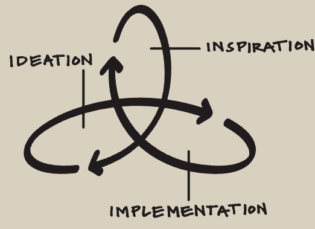

The 3 core activities of design thinking. Source: IDEO (undated).

IDEO U Design thinking process. Source: IDEO U (undated).

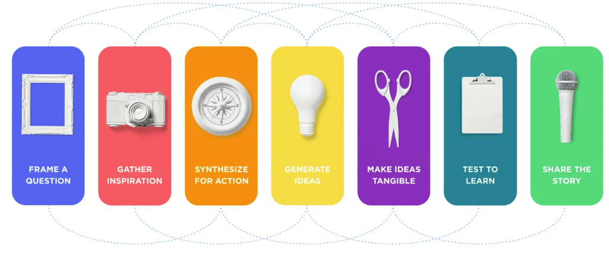

In *Transforming Future Mobility* Coxon et al. (2018) outline how user-centric design processes typical in industrial design can be applied to transport systems. This includes a mapping of various design approaches across dimensions of: research- or design-led; and expert/designer-only or collaborative, as shown in Figure $\ref{fig:Coxon_user-centric_design_approaches}$. They discuss a “fundamental shift…while 20th century design … was the century of the *object*, the 21st century is beginning to be the centurary of the *user*”, and how user-centric design, where “(t)o the designer, the user or passenger is an object of study…reacting to the designed outcomes in the hope of a satisfactory fit”, when developed “still further leads us to a prticipatory approach between design expert and the user…(who) are seen much more as partners in the creation of designed outcomes…as the experts in their own domain and … valued as co-creators…actively involved in idea generation” (Coxon et al. 2018).

Coxon, Selby, Robbie Napper, and Mark Richardson. 2018. *Urban Mobility Design*. Elsevier.

Coxon, Selby, Robbie Napper, and Mark Richardson. 2018. *Urban Mobility Design*. Elsevier.

Mapping user-centred design approaches. Source: Coxon et al (2018b)

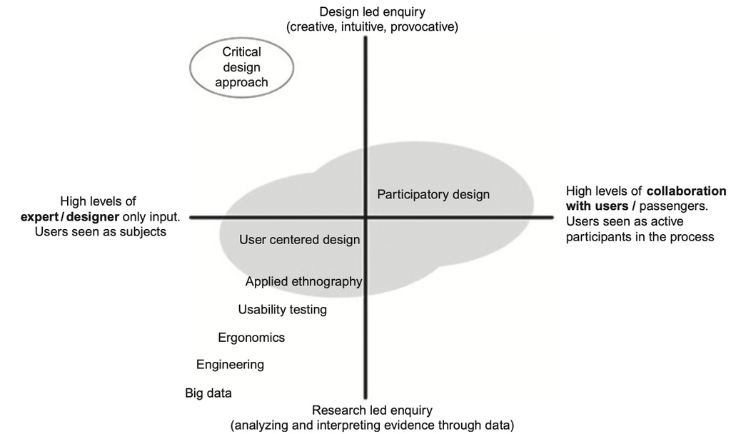

*Critical design approach* is identified as “(at) the most avant-garde end of the spectrum…(where) designers reject the role of design as being limited to the production of objects and instead focus on a rationale that seeks to address matters of concern through provocative and unfamiliar interactions (Malpass, 2017)”(Coxon et al. 2018). At first glance, avant-gardism, provacation and interactions that challenge the status quo would seem to be out of place in transport systems, and having more in common with artistic endeavor and performance. However, there is a long history of such interventions being used in the context of transport systems, especially on roadways, including: street reclaiming; *PARKing Day*; ‘guerilla’ knitting, gardening and bike lanes; tactical urbanism; World Naked Bike Ride, and the No Pants Surbway Ride; Critical Mass; various protest movements relating to bus, bicycle or other lanes, or other topics; the invention of the *woornerf*; and many more (Engwicht 1999; Alisdairi 2014; Lydon et al. 2012; Lydon and Garcia 2015; Ferguson and Blandino 2025; Fucoloro 2013; Gorgan 2019; Morhayim 2012; Guttenberg 1982).

Coxon, Selby, Robbie Napper, and Mark Richardson. 2018. *Urban Mobility Design*. Elsevier.

http://worldnakedbikeride.org/

Engwicht, David. 1999. *Street Reclaiming : Creating Livable Streets and Vibrant Communities*. Sydney : Pluto Press.

Alisdairi, Lana. 2014. “A Cry and a Demand: Tactical Urbanism and the Right to the City.” Master of Urban Planning. PhD thesis, University of Washington.

Lydon, Mike, Dan Bartman, Tony Garcia, Russ Preston, and Ronald Woudstra. 2012. *Tactical Urbanism 2; Short-Term Action, Long-Term Change*. The Street Plans Collaborative.

Lydon, Mike, and Anthony Garcia. 2015. *Tactical Urbanism : Short-Term Action for Long-Term Change*. Island Press.

Ferguson, Beth, and Jordan Scott Blandino. 2025. *Shared Micromobility Vehicle Design and Safety*.

Fucoloro, Tom. 2013. *Guerrilla Road Safety Group ’Politely’ Installs Illegal Bike Lane Protectors on Cherry Street*. Seattle Bike Blog.

Gorgan, Elena. 2019. *Viral Clip of Pedestrian Shooing Off Cars from Seattle Bus Lane Sparks Imitators*. Autoevolution.

Morhayim, Lusi. 2012. “From Counterpublics to Counterspaces: Livable City Advocates’ Efforts to Reshape Cities Through Carfree-Streets Events.” PhD thesis, University of California, Berkeley.

Guttenberg, Albert Z. 1982. “How to Crowd and Still Be Kind-the Dutch Woornerf.” *Humboldt Journal of Social Relations* 9 (2): 100–119.

In part this may be an overlapping of concepts, but something that the parts of the transport policy research field that are embedded within the technical traditions of planning and engineering do not often interact with, or when they do interactions are framed within normative conceptions of legitimacy of road rules, authority and ownership. Reynolds (2020) and Reynolds and Currie (2021) cover this in more detail, including through discussion of the legitimacy of graffiti and who gets to make ‘street art’ and how these topics are informing Movement and Place, Complete Streets, Netowrk Operational Planning and other emerging road network operating approaches (see Delbosc et al. (2018), Reynolds (2025), Dovey et al. (2012); Killen et al. (2017) and others). Public decision making processes are one of the nine pragmatic strategies for legitimising transit prioritisation emerging from Reynolds (2020) and Reynolds and Currie (2021), but the ‘performance’ aspects of legitimising through implementation involved in (7) bottom-up and incremental, (8) pop-ups and (9) trials would appear to link to the elements of *critical design approach* that relate to reframing of the familiar and demonstrating the possibility of change.

Reynolds, James. 2020. “A Framework and Pragmatic Strategies for Transit Priority Implementation.” PhD thesis, Monash University. https://doi.org/10.26180/13377680.v1.

Reynolds, James, and Graham Currie. 2021. “New Approaches and Insights to Managing on-Road Public Transport Priority.” Chap. 10 in *Handbook of Public Transport Research*, edited by Graham Currie. Edward Elgar Publishing Limited.

Delbosc, Alexa, James Reynolds, Wesley Marshall, and Andrew Wall. 2018. “American Complete Streets and Australian SmartRoads: What Can We Learn from Each Other?” *Transportation Research Record*.

Reynolds, James. 2025. “Road Infrastructure.” In *Elgar Encyclopedia of Transport and Society*, edited by John D. Nelson, Corinne Mulley, and Stephen Ison. Edward Elgar Publishing.

Dovey, Kim, Simon Wollan, and Ian Woodcock. 2012. “Placing Graffiti: Creating and Contesting Character in Inner-City Melbourne.” *Journal of Urban Design* 17 (1): 21–41.

Killen, Amy, Selby Coxon, and Robbie Napper. 2017. *A Review of the Literature on Mitigation Strategies for Vandalism in Rail Environments*. Auckland, New Zealand.

Perhaps, to some extent, the ROBUST project itself is akin to such a *critical design approach*, as the trialing of new shared electric mobility technologies might challenge existing concepts of what a mobility hub is, how people might move through environments, motive power and recharging, and the cultural importance of private vehicle ownership. That all sounds somewhat abstract, however, so returning to Coxon et al. (2018) (pp. 189-211) gives some examples of how to actualise Double Diamond and related industrial design approaches in the context of transport systems, including through: *service design*; studies of service / system failures; journey mapping; experiential travel diaries; shadowing; diagrammatic mapping; interviews; questionnaires; cognitive mapping; 3D modeling; visualisation; triangulation methods, being investigator triangulation (multipe researchers), database triangulation and method triangulation; categorisation and subdivision (including through card sorting approaches); brainstorming and *bodystorming*; drawing; 3D printing; immersive simulations, including though involving haptic feedback devices; and agent-based modelling. Further methodologies are discussed in various chapters of *Advancing a Design Approach to Enriching Public Mobility*. These are briefly outlined in the following paragraphs.

Coxon, Selby, Robbie Napper, and Mark Richardson. 2018. *Urban Mobility Design*. Elsevier.

which “looks beyond the object or the space to capture and integrate a conceptual plan that engages the organisation of people, infrastructure, communication and the material components of a ser- vice” (p.189).

Involving physical mock ups.

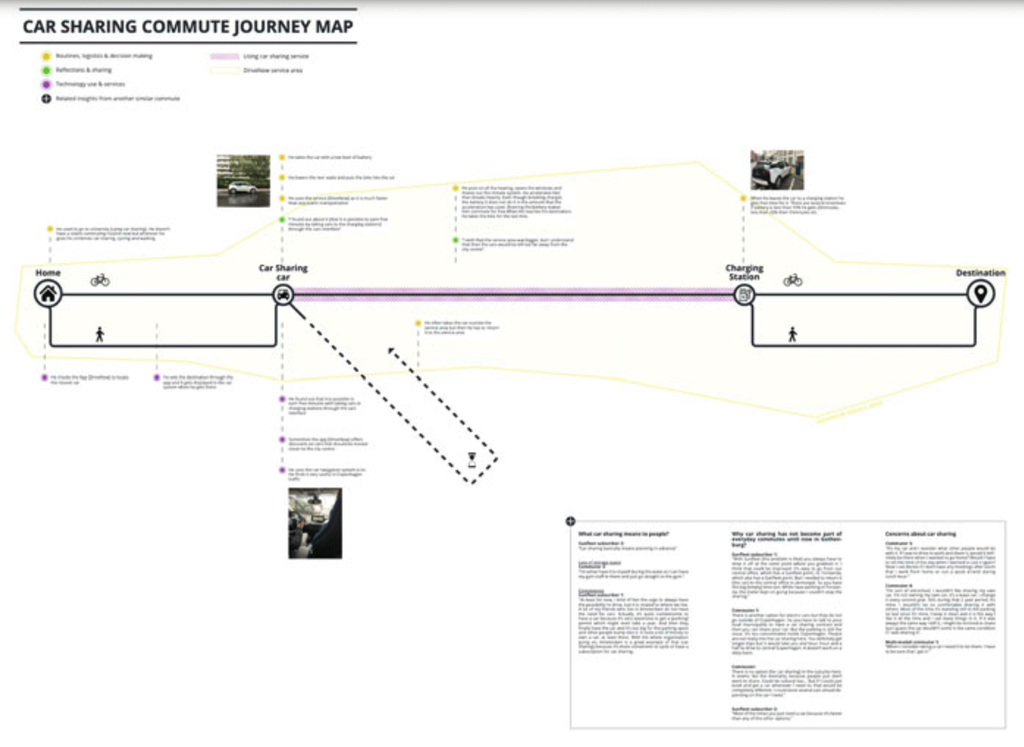

An example of a how to map a person’s commute routine and how different modes of transportation become part of it. Map created by Kaspar Raats and Katalin Osz, Source: Pink et al (2021).

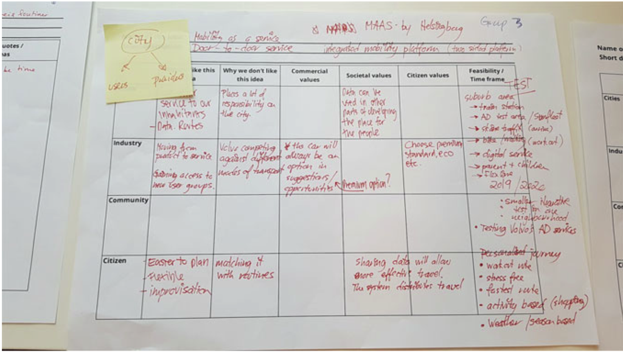

Map of different stakeholder perspectives in creating a joint mobility technology. Photograph by Thomas Lindgren Source: Pink et al (2021)

Pink et al. (2021) use: design anthropology; in-car video enthographies; *Wizard of Oz studies*; workshops with ‘probes’ such as disruption cards, video drive-along clips, journey maps (see Figure $\ref{fig:Pink_commute_map}$, prompt tables (see Figure $\ref{fig:Pink_prompt_tables}$) storyboards and pain point maps, and facilitated discussions; a *Drive-Me* study involving use of research vehicles for 18 months by families, during which researchers undertook “home visits, drive and commute alongs, speculative future scenarios, discussions and mapping activities over a shared take-away meal…(which) included mapping the technologies and ‘stuff’ kept in the car” (Pink et al. 2021);

Pink, Sarah, Rachel Charlotte Smith, Vaike Fors, et al. 2021. “Mobility as a Service Through Design: A Human Approach.” Chap. 1 in *Advancing a Design Approach to Enriching Public Mobility*, edited by Selby Coxon and Robbie Napper. Springer.

encompassing concepts related to *emergence*, *improvisation*, *knowing*, and *learning*

reenacting routines with participants

Autonomous vehicle studies where a hidden researcher drives the car to simuluate a driverless vehicle

Pink, Sarah, Rachel Charlotte Smith, Vaike Fors, et al. 2021. “Mobility as a Service Through Design: A Human Approach.” Chap. 1 in *Advancing a Design Approach to Enriching Public Mobility*, edited by Selby Coxon and Robbie Napper. Springer.

Visual conflict framing of train factors. Diagram referenced from Coxon [9]. Source: Fridman and Coxon (2021)

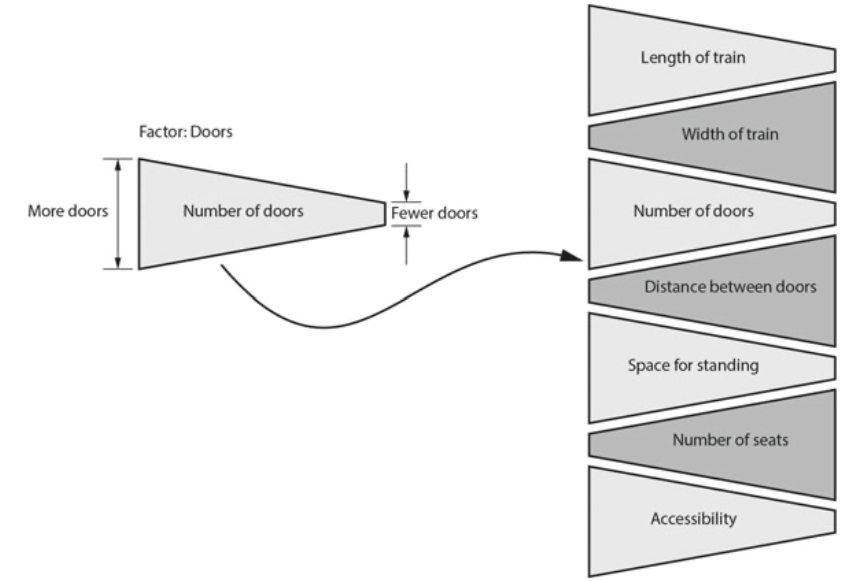

Visual conflict re-framing of bus factors. Source: Fridman and Coxon (2021)

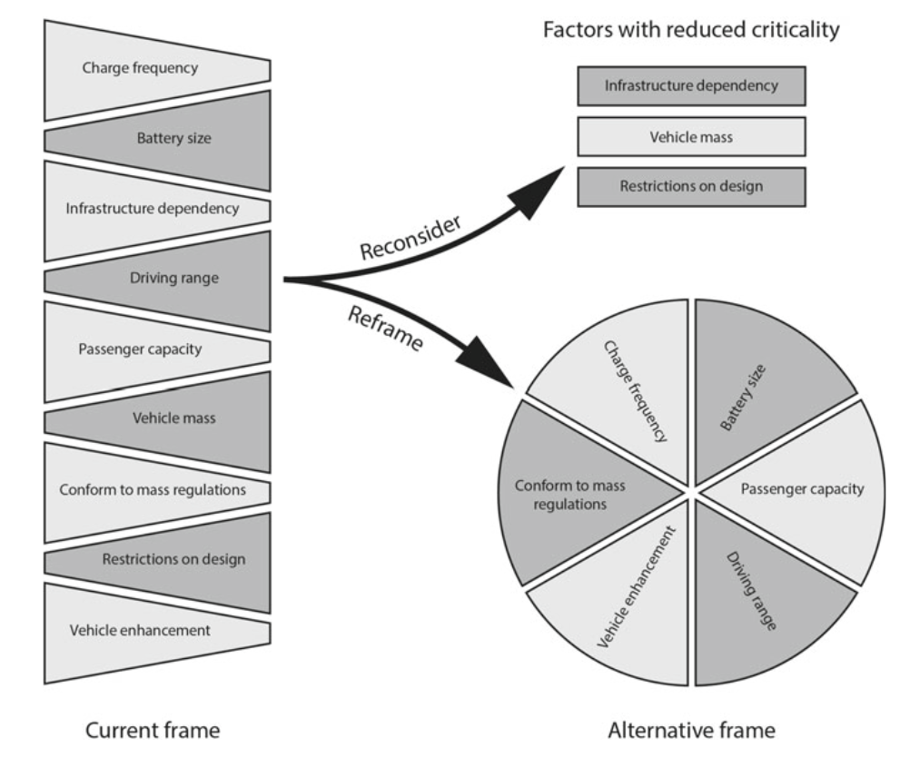

Fridman and Coxon (2021) discuss visual conflict framing (Figure $\ref{@Fridman_train_doors}$) and reframing (Figure $\ref{@Fridman_reframe}$) in which a problem is approached as if it is a problem with something else^[“…if the problem of battery weight was approached as if it was problem of demand responsiveness, then the solution should be to design using modularity” where smaller buses are connected and disconnected according to demand, rather than carrying around a larger bus (and battery) just for the peak demand (p.32)](Fridman and Coxon 2021);

Fridman, Ilya, and Selby Coxon. 2021. “Visual Conflict Framing in Public Transport Innovation.” Chap. 2 in *Advancing a Design Approach to Enriching Public Mobility*, edited by Selby Coxon and Robbie Napper. Springer.

Fridman, Ilya, and Selby Coxon. 2021. “Visual Conflict Framing in Public Transport Innovation.” Chap. 2 in *Advancing a Design Approach to Enriching Public Mobility*, edited by Selby Coxon and Robbie Napper. Springer.

Woodcock et al. (2021) uses the Hexagon Spindle (HS) Model together with surveys, interviews, observations, focus group discussions and expert interviews.

Woodcock, A., S. Iqbal, and J. Osmond. 2021. “Unbounded Ergonomics: Addressing the Wicked Problem of Gender Transport Poverty in Karachi Through the Application of the Hexagon-Spindle Model.” Chap. 3 in *Advancing a Design Approach to Enriching Public Mobility*, edited by Selby Coxon and Robbie Napper. Springer.

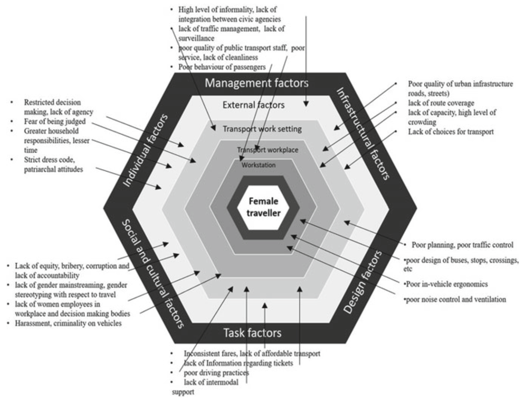

KPIs for female travellers mapped on to the HS model. Source: Woodcock et al (2021).

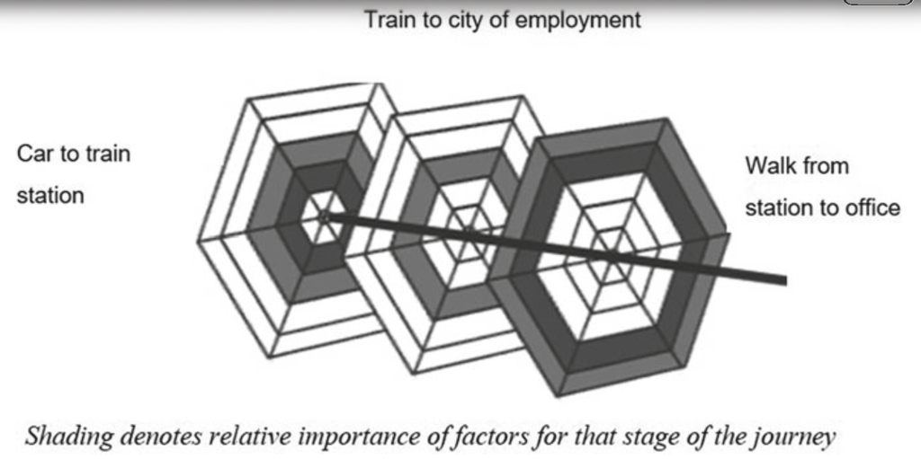

Crowd sourcing is used as a data collection method in Matthewson and Kalms (2021), through an online mapping platform that members of the public can use to report unsafe locations. This appears largely similar to recent approaches adopted in the context of cyclist safety (BikeSpot undated), where official statistics may similarly not reflect real-world conditions.

Matthewson, Gill, and Nicole Kalms. 2021. “Unwanted Sexual Behaviour and Public Transport: The Imperative for Gender-Sensitive Co-Design.” Chap. 4 in *Advancing a Design Approach to Enriching Public Mobility*, edited by Selby Coxon and Robbie Napper. Springer.

BikeSpot. undated. *BikeSpot*. https://www.bikespot.org/.

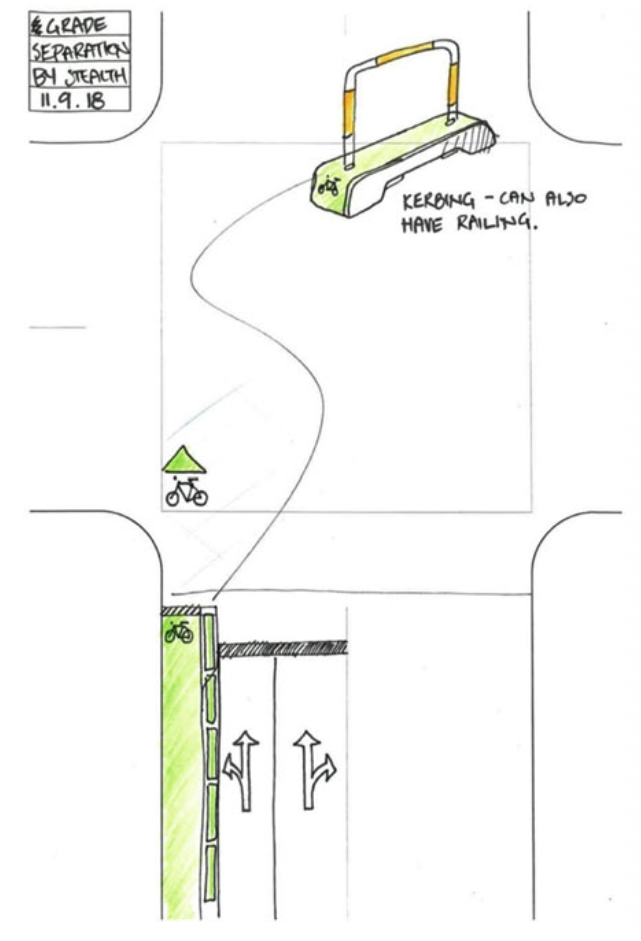

An example of a two-dimensional drawing used in the research. Source: Napper et al (2021).

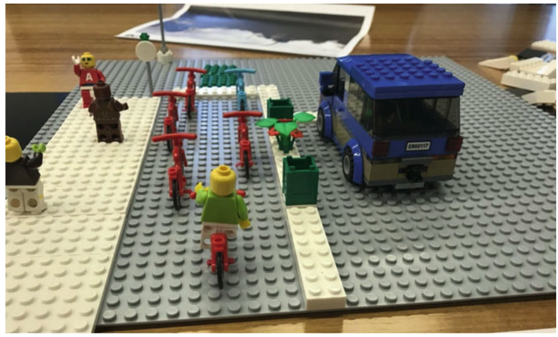

Typical LEGO model used in the research. Source: Napper et al (2021).

Napper et al. (2021) describes how drawing and LEGO models can be used for exploration, development and engagement in the context of cross-disciplinary research at the intersection of design, transport and law. Along similar line Johnson and Coxon (2021) presents outputs from using a storyboarding approach.

Napper, Robbie, Marilyn Johnson, and Vanessa Johnston. 2021. “Safety, Design and Law: A New Interdisciplinary Approach to Bicycle Rider Road Safety.” Chap. 6 in *Advancing a Design Approach to Enriching Public Mobility*, edited by Selby Coxon and Robbie Napper. Springer.

Johnson, Mark, and Selby Coxon. 2021. “ReinCARnation: The Emergence of Time over Ownership as the True Brand Value and Driving Force for Design.” Chap. 8 in *Advancing a Design Approach to Enriching Public Mobility*, edited by Selby Coxon and Robbie Napper. Springer.

Gaitan (2021) describes a large-scale and iterative testing method based on user experience design approach through facilitated task completion by members of the public within a one-to-one scale mock-up of a railway station. This appears to be a rapid form of prototyping and seeking stakeholder feedback, which is also used in Rane et al. (2021), Jolivet and Coxon (2021), Killen (2021) and Gray et al. (2021).

Gaitan, Carolina. 2021. “Implementing a User Experience Design Approach in Melbourne’s Public Transport System: The Case of Wayfinding and Customer Information Design at Flinders Street Station.” Chap. 9 in *Advancing a Design Approach to Enriching Public Mobility*, edited by Selby Coxon and Robbie Napper. Springer.

Rane, Mandar, Jaikishan Patel, Kalagouda Patil, Aditi Kulkarni, Braj Bhushan, and Hriday Gami. 2021. “The Challenges of Designing the Rail Network Map/Diagram as the Critical, Missing, Transit Infrastructure for Mumbai.” Chap. 10 in *Advancing a Design Approach to Enriching Public Mobility*, edited by Selby Coxon and Robbie Napper. Springer.

Jolivet, Sylvain, and Selby Coxon. 2021. “Developing a Design Research Approach to Inter-City Rail Carriage Interiors.” Chap. 11 in *Advancing a Design Approach to Enriching Public Mobility*, edited by Selby Coxon and Robbie Napper. Springer.

Killen, Amy. 2021. “Mitigating Rail Vandalism Through Design Intervention.” Chap. 14 in *Advancing a Design Approach to Enriching Public Mobility*, edited by Selby Coxon and Robbie Napper. Springer.

Gray, Susan, Lance Glover, and Allison Porterfield. 2021. “Practising the Art of Wayfinding Design and Finding the Way to Artwork Materials: Designing Los Angeles County’s Transit Future, Applying Lessons Learned in New Project Delivery Methods for Metro Signage and Artwork.” Chap. 15 in *Advancing a Design Approach to Enriching Public Mobility*, edited by Selby Coxon and Robbie Napper. Springer.

Beyond these approaches there appear to be a wide range of techniques, formats and other ways in which feedback or input from users, stakeholders, experts or others might be sort in research, marketing, design or other endeavours. Bhandari and Hallowell (2021) present a heirarchy of common methods, including Delphi, Nominal Group and Focus Group. Notably there are a large number of variations, lacking formal names, which Bhandari et al (2021) suggests might arise because of a desire to use one of the named methods but constraints leading to compromises and use a something that is not quite the same “(e.g., modified Delphi)”.

Bhandari, Siddharth, and Matthew R Hallowell. 2021. “Identifying and Controlling Biases in Expert-Opinion Research: Guidelines for Variations of Delphi, Nominal Group Technique, and Focus Groups.” *Journal of Management in Engineering* (New York) 37 (3).

Hierarchy of common opinio-based research methods. Source: Bhandari and Hallowell (2021).

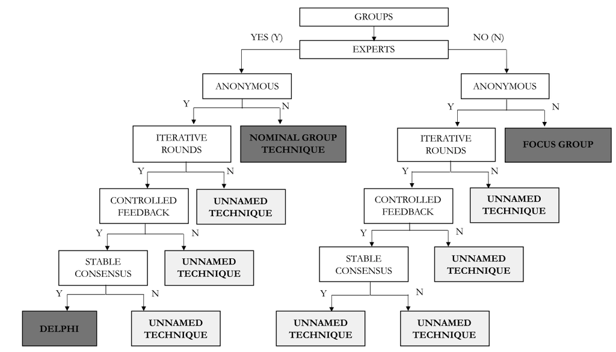

Bhandari et al (2021) suggests that researchers and practitioners should instead focus on the control-types used, be it: single-blinded anonymity; double-blinded anonymity; iterative rounds with statistical feedback; iterative rounds with descriptive feedback; randomizations; background checks; and/or giving participants a sense of ownership and/or personal accountability for the outcomes. These are crosstabulated to common biases that might impact individual and group decision-making (Figure $\ref{fig:Bharndari_bias}$), leading to a synthesis of how control options might be combined to remove some or all of the potential biases (Figure $\ref{fig:Bharndari_options}$), although it notes that there is a need for further research that “not only should seek to investigate the effectiveness of various pupular debaising stretegies from literature fore the CEM (construction engineering and management) domain but also should establish empirically the balure of research controls in managing and minimizing biases for opinion-based research” (Bhandari et al 2021)

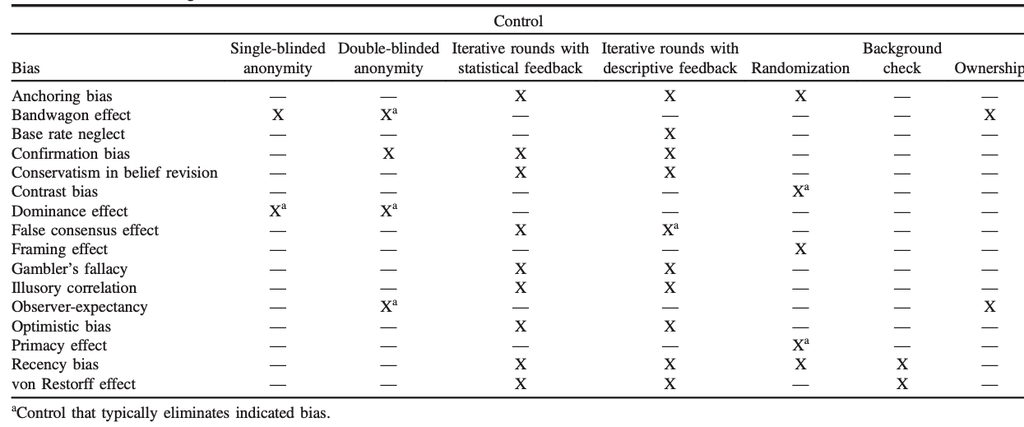

Cross tabulation of cognitive biases and research controls. Source: Bhandari and Hallowell (2021).

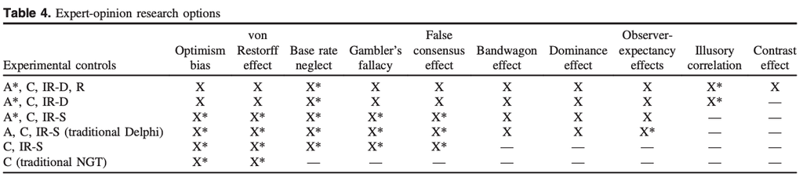

Expert-opinion research options. Source: Bhandari and Hallowell (2021).

In summary, this section has briefly discussed some of the background context to this study, including: dockless bike / scooter sharing and shared electric mobility hubs; hype-cycles; CPTED and graffiti; industrial design and the Double Diamond design processes; public involvement in decision-making and the “Arnstein Gap”; user-centred design approaches, *critical design approach* and its similarities to tactical urbanism, street protests and pop-ups; emerging methodologies in transport such as Movement and Place, Complete Streets and Network Operating Planning; and applications of industrial design methodologies to transport systems; and the potential biases that might be at play when using Nominal Group Technique, Focus Groups, the Delphi Method or other forms of research where group opinion is sought. Clearly there is a lot of overlap and similarities across these topics, but much breadth that is reflective perhaps of the multi- and inter-disciplinary nature of transport systems generally, but also shared electric mobility hubs in particular. As discussed in the following section, just to get the ROBUST sites in Letterkenny, Galway, Waterford and Dundrum implemented in their initial forms has required much input from: electrical, civil, mechanical and other engineers; computer scientists, programmers and others within information technology and related sectors; academics, practitioners across both governmental and private organisations; and many more; and the adaptation and development of existing vehicle, infrastructure and other technologies

The research described in this paper, however, seeks to build upon the ‘initial offers’ implemented in the ROBUST project, including through adopting of user-centred, participatory and other design approaches. As discussed above, and in Reynolds et al. (in draftingc), the research literature related to shared electric mobility hubs appears to be relatively limited, which is unsurprising given the rapid and recent development of technologies in this field. There does not appear to have been much research attention given to user input about how the design and operation of ‘mobility hubs’ might be improved. This is likewise unsurprising, given that there are few shared electric mobility hubs in existance, and that the ROBUST project represents an early trial (and prototype). As such, the research reported in this paper has use the ROBUST sites in their initial forms as part of exploratory case research to develop new understandings of how shared electric mobility hubs might be designed and implemented, and how user, community and stakeholder mobility and other needs might better be fulfilled towards the goal of improved social, environmental and economic outcomes. The next section, therefore, describes the case research approach adopted, further details of the ‘initial offers’ implemented in each location, and the industrial design approaches and other methods used in this study.

Reynolds, James, Amaya Vega, Brian McCann, Agnieszka Stefaniec, and Brian Caulfield. in draftingc. “ROBUST - Electric shaRed mOBility hUbS Trial: Science Mapping Analysis and Literature Review.” *TBC*, in drafting.

# Methodology

## Case research

Reynolds, James, Amaya Vega, Brian McCann, Agnieszka Stefaniec, and Brian Caulfield. in draftingb. “Exploring Public Policy and Decision-Making During Shared e-Mobility Hub Implementation: Ireland’s ROBUST Trial.” *TBC*, in drafting.

Reynolds, James, Amaya Vega, Brian McCann, Agnieszka Stefaniec, and Brian Caulfield. in draftinga. “Exploring Location Optimisation, Constraints and Challenges Associated with Shared e-Mobility Hubs.” *TBC*, in drafting.

Atlantic Technological University. 2025b. *One of Ireland’s First eMobility eHub Established in Westside, Galway, Serving West and Northwest*. https://www.atu.ie/news/one-of-irelands-first-emobility-ehub-established-in-westside-galway-serving-west-serving-west-and-northwest.

Atlantic Technological University. 2025a. *New Sustainable Transport eHub Opens in Letterkenny*. https://www.atu.ie/news/new-sustainable-transport-ehub-opens-in-letterkenny.

Waterford City and County Council. 2025. *New eMobility eHub Launches in Ballybricken, Waterford*. https://waterfordcouncil.ie/new-emobility-ehub-launches-in-ballybricken-waterford/.

While members of the ROBUST research team had been involved in the development, siting and other aspects of implementation prior to the launch of each hub, by happenstance there was a switch-over of personnel through 2025 and 2026, with the lead author starting in September 2025, which provides a useful demarcation point for the purposes of this case study. Hence, September 2025 is defined as the commencement of the ‘post-initial-implementation co-design-related activities’ as it represents a transition (and handover) from many of those involved in the development of the ‘initial offer’ and to this research. The following table maps research activities, in chronological order, to each of the Double Diamond design phases.

Research activities mapped to Double Diamond stages

[output not shown]

As shown in the above table, the research included exploration of the hub infrastructure and discussions with current and former team members to *discover* the shared electric mobility hubs’ ‘initial offer’ features, technology and useability (as at September 2025). Through early 2026 website, signage and instructional video designs were iterated, along with engagement with the ROBUST app developer to discover features of the app (as implemented) and define problems. As well, materials were developed to support and inform the *discovery-*, *definition-*, *development-* and *delivery-*activity at stakeholder workshops held in May.

# Results

## Discover

### Exploring the ‘initial offers’

The electric bicycles have a inbuilt and wireless charging system, which operates through the kick-stand (pictured). This needs to be placed on a yellow coloured part of the parking area, next to indicator lights that change from blue to green when the connection is made. A locking mechanism is attached to one of the wheels of each of the bikes, along with instructions to “SCAN HERE” for a QR code to access the app, which provides the functionality for hiring, returning and paying for usage. The locking mechanism is remotely controlled by the app and associated system, which will release the lock when a hire is commenced. This mechanism, however, does not appear to allow for remote locking, as there is a knob that users need to move downwards to engage the lock.

[figure not shown]

Letterkenny ROBUST hub: electric bikes

[figure not shown]

Electric bike kickstand detail

[figure not shown]

Electric bike lock detail

[figure not shown]

Letterkenny ROBUST hub: cars and charger

### Maps for workshops

## Define

PROBLEM: Mobility hubs are not a “bespooke” solution Rather, they are an amalgamation of already existing tech and systems (MOBY and ENTERPRISE) that already have their own processes, pricing etc.

## Develop

## Developing a draft website and instructional video (January 2026)

### Signage improvements (early 2026)

## Deliver

### Co-design workshops

Stakeholders

General Public

# Discussion

# Conclusions

## Directions for future research

Author contribution matrix, as per CRediT (Contribution Roles Taxonomy

| Component | NArmstrong | BCaulfield | BMcCann | SMoslem | MOMahony | JReynolds | AStefaniec | AVega |
| --- | --- | --- | --- | --- | --- | --- | --- | --- |
| Conceptualization |  | X |  |  |  | X | X |  |
| Data Curation |  |  |  |  |  |  |  |  |
| Formal Analysis |  |  |  |  |  |  |  |  |
| Funding Acquisition |  | X |  |  |  |  | X |  |
| Investigation | X | X |  |  |  | X |  |  |
| Methodology |  |  |  |  |  | X |  |  |
| Project Administration |  |  |  | X |  | X |  |  |
| Resources |  |  |  |  |  |  |  |  |
| Software |  |  |  |  |  |  |  |  |
| Supervision |  |  | X |  |  |  |  | X |
| Validation |  |  |  |  |  |  |  |  |
| Visualization |  |  |  |  |  |  |  |  |
| Writing – Original Draft Preparation |  |  |  |  |  | X |  |  |
| Writing – Review & Editing |  |  |  |  |  |  |  |  |

# References